# Examen_AS

Thibault QUEMENER - Christine FOUQUE

21/05/2021

## Objectif du projet

Dans le cadre de ce projet, nous travaillerons sur la base de données SwissLabor. Nous essaierons de construire plusieurs modèle afin de predire la variable binaire “Participation”.

## Télechargement des packages

```r
library(readr)
library(class)
library(MASS)
library(ggplot2)
library(ROCR)
library(GGally)
library(caret)
library(ISLR)
library(rpart)
library(rpart.plot)
library(tidyverse)
set.seed(1)
```

## Description de la base de données

SwissLabor est une base de données qui comprend 872 observations et 7 variables. + participation : c’est une variable qualitative, qui indique si l’individu participe ou non au marché du travail. + income : Logarithme du revenu hors travail ou du revenu + âge : ge en décennies (années divisées par 10). + education : Années d’éducation + youngkids : Nombre de jeunes enfants de moins de 7 ans + oldkidsold : Nombre d’enfants plus âgés de plus de 7 ans + foreign : variable factorielle (yes, no). L’individu est-il un étranger (c’est-à-dire non suisse) ?

## Préparation des données

Nous préparons les données en supprimant la première colone du dataset. En effet, celle-ci contient seulement le numéro de ligne des individus. Cette information n’est donc pas utile pour notre analyse. Nous transformons les variables “Participation” et “Foreign” en données de type factor pour les traiter dans nos modèles.

Après observations de la base nous voyons que celle-ci ne possède pas de valeurs NA. Nous n’avons pas d’identifiants uniques (numéro, ID…) pour s’assurer qu’ il n’y ai pas de doublons. Nous partons donc de l’hypothèse selon laquelle il n’y a pas de doublons dans cette base.

```r
SwissLabor<-SwissLabor[,-c(1)]
SwissLabor$participation<-as.factor(SwissLabor$participation)
SwissLabor$foreign<-as.factor(SwissLabor$foreign)
```

## Nettoyage des données

Nos données étant propres, nous n’avons pas besoin d’effectuer des modifications afin de nettoyer celle-ci.

## Statistiques Descriptives

Nous réalisons brièvement quelques analyses de statistiques descriptive afin de nous appropier nos données.

### Income

```r
par(mfrow = c(1, 3))
h_income <-hist(SwissLabor$income)
h_income
```

[output not shown]

```
## $breaks
##  [1]  7.0  7.5  8.0  8.5  9.0  9.5 10.0 10.5 11.0 11.5 12.0 12.5
##
## $counts
##  [1]   1   0   0   0   4  25 225 464 123  25   5
##
## $density
##  [1] 0.002293578 0.000000000 0.000000000 0.000000000 0.009174312 0.057339450
##  [7] 0.516055046 1.064220183 0.282110092 0.057339450 0.011467890
##
## $mids
##  [1]  7.25  7.75  8.25  8.75  9.25  9.75 10.25 10.75 11.25 11.75 12.25
##
## $xname
## [1] "SwissLabor$income"
##
## $equidist
## [1] TRUE
##
## attr(,"class")
## [1] "histogram"
```

```
##    Min. 1st Qu.  Median    Mean 3rd Qu.    Max.
##   7.187  10.472  10.643  10.686  10.887  12.376
```

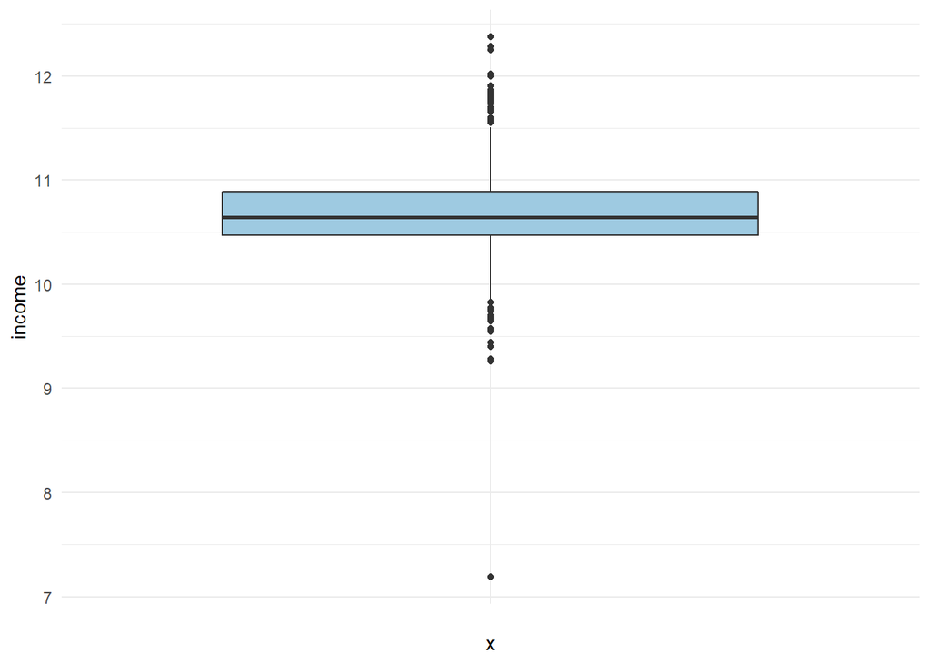

```r
p1 <- ggplot(SwissLabor) +
  aes(x = "", y = income) +
  geom_boxplot(fill = "#9ECAE1") +
  theme_minimal()
p1
summary(SwissLabor$income)
```

Il serait intéressant de se renseigner sur cet individu spécifiquement et d’essayer de réaliser une modélisation sans celui-ci car il peut avoir une influence notable.

### Age

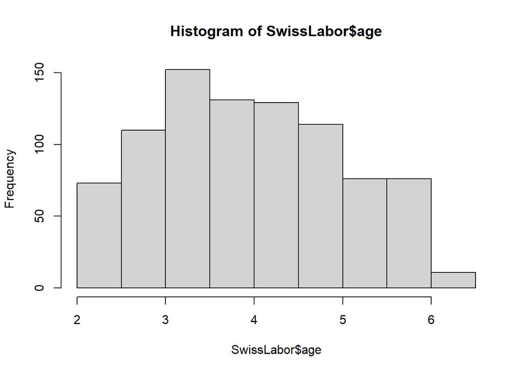

```r
h_age <-hist(SwissLabor$age)
```

```r
h_age
```

```
## $breaks
##  [1] 2.0 2.5 3.0 3.5 4.0 4.5 5.0 5.5 6.0 6.5
##
## $counts
## [1]  73 110 152 131 129 114  76  76  11
##
## $density
## [1] 0.16743119 0.25229358 0.34862385 0.30045872 0.29587156 0.26146789 0.17431193
## [8] 0.17431193 0.02522936
##
## $mids
## [1] 2.25 2.75 3.25 3.75 4.25 4.75 5.25 5.75 6.25
##
## $xname
## [1] "SwissLabor$age"
##
## $equidist
## [1] TRUE
##
## attr(,"class")
## [1] "histogram"
```

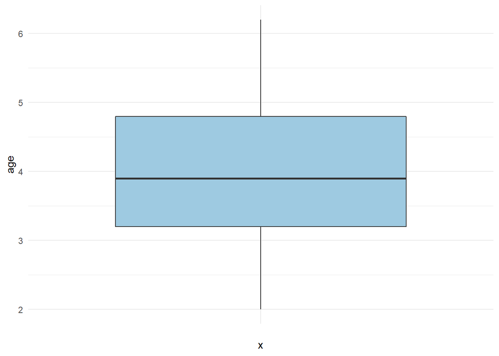

```r
p2 <- ggplot(SwissLabor) +
  aes(x = "", y =age
      ) +
  geom_boxplot(fill = "#9ECAE1") +
  theme_minimal()
p2
```

La distribution de l’age suit globalement une loi Normale Nous n’observons pas d’outlier sur cette variable.Les ages sont dispersés entre 2 decades et 6.2 decades , la moyenne est de 4 decade et l’ecart type de 1.06 decade.

### Participation

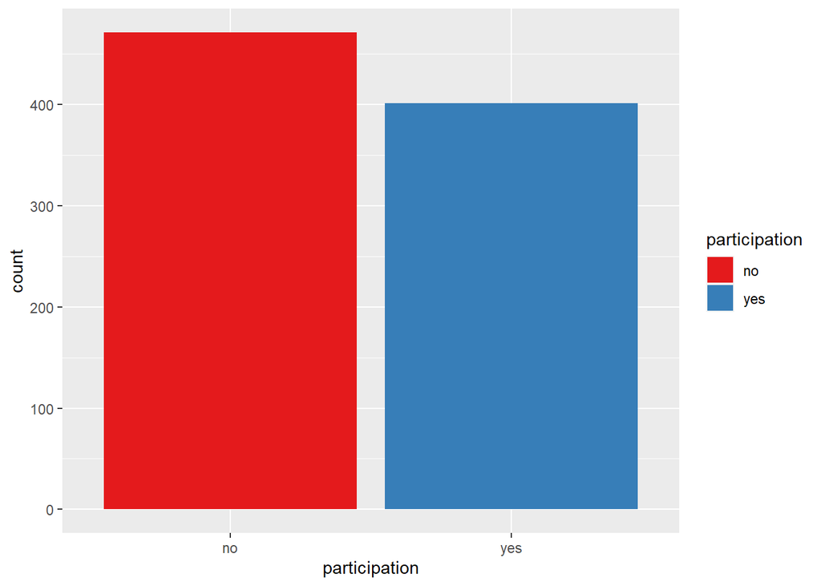

```r
p7<-ggplot(SwissLabor, aes(x = participation, fill = participation)) + geom_bar() +
  scale_fill_brewer(type="qual", palette = 6)
p7
```

```r
summary(SwissLabor$participation)
```

```
##  no yes
## 471 401
```

# Prédiction de notre variable

Nous allons maintenant construire plusieurs modèles afin de prédire la variable “Participation” de notre dataset. Pour cela, nous nous appuierons sur l’ensemble des variables de notre dataset.

## Regression Logistique

Nous commencerons par diviser nos données en deux dataset. Un dataset d’apprentissage et un dataset de test. Nous construirons notre dataset d’apprentissage avec 70% des individus de notre base SwissLabor. Nous conserverons les 30% restant dans un dataset de test afin d’évaluer la performance de notre modèle.

```r
Default_split<- sample(1:nrow(SwissLabor), round(nrow(SwissLabor)*0.7))
glm.train <- SwissLabor[Default_split, ]
glm.test  <- SwissLabor[-Default_split, ]
```

Nous commencerons par construire une regression logisitique prennant en compte l’ensemble des variables de notre jeu de données. Nous cherchons à predire une variable binomiale donc nous sélectionnons l’argument “binomial” pour le paramètre family.

```r
full.model <- glm(participation~. , data = glm.train,family = "binomial")
summary(full.model)
```

```
##
## Call:
## glm(formula = participation ~ ., family = "binomial", data = glm.train)
##
## Deviance Residuals:
##     Min       1Q   Median       3Q      Max
## -1.9518  -0.9692  -0.5831   1.0795   2.1791
##
## Coefficients:
##              Estimate Std. Error z value Pr(>|z|)
## (Intercept) 10.744520   2.663226   4.034 5.47e-05 ***
## income      -0.865474   0.252626  -3.426 0.000613 ***
## age         -0.453445   0.108002  -4.198 2.69e-05 ***
## education    0.015067   0.035398   0.426 0.670359
## youngkids   -1.135606   0.202856  -5.598 2.17e-08 ***
## oldkids     -0.004524   0.090935  -0.050 0.960319
## foreignyes   1.541479   0.241685   6.378 1.79e-10 ***
## ---
## Signif. codes:  0 '***' 0.001 '**' 0.01 '*' 0.05 '.' 0.1 ' ' 1
##
## (Dispersion parameter for binomial family taken to be 1)
##
##     Null deviance: 842.46  on 609  degrees of freedom
## Residual deviance: 729.39  on 603  degrees of freedom
## AIC: 743.39
##
## Number of Fisher Scoring iterations: 4
```

Dans ce modèle, nous remarquons que certaines variables ne sont pas significatives, nous chercherons un nouveau modèle plus optimisé. Pour cela nous réaliserons une selection des variables en mode stepWise. Par cette méthode, nous chercherons à minimiser notre AIC.

```r
step.model<- stepAIC(full.model,direction = "both",trace=T)
```

```
## Start:  AIC=743.39
## participation ~ income + age + education + youngkids + oldkids +
##     foreign
##
##             Df Deviance    AIC
## - oldkids    1   729.40 741.40
## - education  1   729.58 741.58
## <none>           729.39 743.39
## - income     1   742.42 754.42
## - age        1   747.78 759.78
## - youngkids  1   765.81 777.81
## - foreign    1   774.33 786.33
##
## Step:  AIC=741.4
## participation ~ income + age + education + youngkids + foreign
##
##             Df Deviance    AIC
## - education  1   729.59 739.59
## <none>           729.40 741.40
## + oldkids    1   729.39 743.39
## - income     1   743.01 753.01
## - age        1   749.49 759.49
## - youngkids  1   771.37 781.37
## - foreign    1   774.42 784.42
##
## Step:  AIC=739.59
## participation ~ income + age + youngkids + foreign
##
##             Df Deviance    AIC
## <none>           729.59 739.59
## + education  1   729.40 741.40
## + oldkids    1   729.58 741.58
## - income     1   743.35 751.35
## - age        1   750.80 758.80
## - youngkids  1   771.38 779.38
## - foreign    1   779.14 787.14
```

```r
summary(step.model)
```

```
##
## Call:
## glm(formula = participation ~ income + age + youngkids + foreign,
##     family = "binomial", data = glm.train)
##
## Deviance Residuals:
##     Min       1Q   Median       3Q      Max
## -1.9445  -0.9732  -0.5899   1.0815   2.1789
##
## Coefficients:
##             Estimate Std. Error z value Pr(>|z|)
## (Intercept)  10.6070     2.6152   4.056 4.99e-05 ***
## income       -0.8372     0.2361  -3.546 0.000392 ***
## age          -0.4586     0.1020  -4.498 6.87e-06 ***
## youngkids    -1.1290     0.1898  -5.948 2.72e-09 ***
## foreignyes    1.5045     0.2259   6.660 2.74e-11 ***
## ---
## Signif. codes:  0 '***' 0.001 '**' 0.01 '*' 0.05 '.' 0.1 ' ' 1
##
## (Dispersion parameter for binomial family taken to be 1)
##
##     Null deviance: 842.46  on 609  degrees of freedom
## Residual deviance: 729.59  on 605  degrees of freedom
## AIC: 739.59
##
## Number of Fisher Scoring iterations: 4
```

La performance entre notre modèle optimale et notre modèle complet est proche. Nous remarquons que l’AIC de notre modèle optimale est légèrement inférieure à celle de notre modèle complet. En revanche, la somme de la deviance residuel est légèrement supérieure dans notre modèle optimisé, notre modèle est donc légèrement moins performant sur ce point. Nous ferons néanmoins le choix de conserver notre modèle optimisé celui-ci offre une meilleure AIc et contient moins de variables.

Nous testons les performances de notre dataset à l’aide de notre second jeu de données de test.

```r
glm.test$glm_predict<-predict(step.model,newdata=glm.test,type="response")
glm.test$glm033<-ifelse(glm.test$glm_predict>0.33,"yes","no")
cm<-table(predicted=glm.test$glm033, actual=glm.test$participation)


cm<-confusionMatrix(cm,positive = "yes")
cm
```

```
## Confusion Matrix and Statistics
##
##          actual
## predicted no yes
##       no  52  20
##       yes 92  98
##
##                Accuracy : 0.5725
##                  95% CI : (0.5102, 0.6332)
##     No Information Rate : 0.5496
##     P-Value [Acc > NIR] : 0.2477
##
##                   Kappa : 0.1816
##
##  Mcnemar's Test P-Value : 1.961e-11
##
##             Sensitivity : 0.8305
##             Specificity : 0.3611
##          Pos Pred Value : 0.5158
##          Neg Pred Value : 0.7222
##              Prevalence : 0.4504
##          Detection Rate : 0.3740
##    Detection Prevalence : 0.7252
##       Balanced Accuracy : 0.5958
##
##        'Positive' Class : yes
##
```

Nous obtennons une précision proche de 60%, avec une sensibilité proche de 85% et une specificité voisine de 35%. Nous tenterons d’augmenter ce seuil, en convertissant les individus dont la probabilité prédite est supérieur à 0.66. Cette valeeur semble être la valeur nous garantissant les meilleurs résultats.

```r
glm.test$glm_predict<-predict(step.model,newdata=glm.test,type="response")
glm.test$glm033<-ifelse(glm.test$glm_predict>0.66,"yes","no")
cm<-table(predicted=glm.test$glm033, actual=glm.test$participation)


cm<-confusionMatrix(cm,positive = "yes")
cm
```

```
## Confusion Matrix and Statistics
##
##          actual
## predicted  no yes
##       no  127  79
##       yes  17  39
##
##                Accuracy : 0.6336
##                  95% CI : (0.5721, 0.692)
##     No Information Rate : 0.5496
##     P-Value [Acc > NIR] : 0.003595
##
##                   Kappa : 0.223
##
##  Mcnemar's Test P-Value : 4.791e-10
##
##             Sensitivity : 0.3305
##             Specificity : 0.8819
##          Pos Pred Value : 0.6964
##          Neg Pred Value : 0.6165
##              Prevalence : 0.4504
##          Detection Rate : 0.1489
##    Detection Prevalence : 0.2137
##       Balanced Accuracy : 0.6062
##
##        'Positive' Class : yes
##
```

```r
exp(coef(step.model))
```

```
##  (Intercept)       income          age    youngkids   foreignyes
## 4.041830e+04 4.329064e-01 6.321923e-01 3.233707e-01 4.502095e+00
```

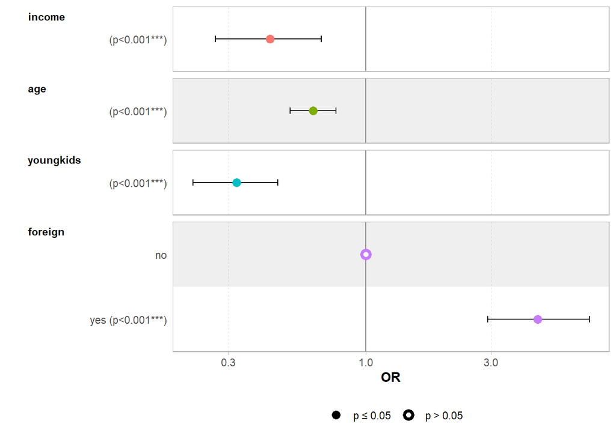

```r
ggcoef_model(step.model, exponentiate = TRUE)
```

## KNN

Nous réaliserons maintenant un second modèle sur l’algorithme de classification des K-plus proches voisins. Pour cela, comme pour la régression logistique, nous allons creer deux jeux d’apprentissage et de test. Afin de gagner en robustesse sur nos données , nous standardisons les variables numeriques.

```r
SwissLabor$participation<-ifelse(SwissLabor$participation == "yes", 1,0)
SwissLabor$foreign<-ifelse(SwissLabor$foreign == "yes", 1,0)
```

```r
#standardisation des variables
deflt_s<-SwissLabor[-c(1,7)]
deflt_s<-as.data.frame(scale(deflt_s))
deflt_s$pred<-SwissLabor$participation

#data splitting #
Default_split<- sample(1:nrow(deflt_s), round(nrow(deflt_s)*0.7))
deflt_train <- deflt_s[Default_split, ]
deflt_test  <- deflt_s[-Default_split, ]
##D?f matrice des var explicatives et de la variable r?ponse
train.x=deflt_train[,-6]
test.x=deflt_test[,-6]
train.y=deflt_train[,6]
test.y=deflt_test[,6]
```

Avec l’algorithme KNN, nous devons separer notre variable cible de nos variables explicatives c’est pour cela que nous séparons nos données en 4.

Une fois nos données préparées, nous lançons notre algortihme KNN avec K=1. Nous modifierons cette valeur en trouvant la valeur de K permettant d’optimiser notre modèle.

```r
set.seed(1)
knn_pred_y = knn(train.x, test.x, cl=train.y, k = 1)
table(knn_pred_y, test.y)
```

```
##           test.y
## knn_pred_y  0  1
##          0 91 64
##          1 51 56
```

```r
#erreur de classification pour k=1
mean(knn_pred_y != test.y)
```

```
## [1] 0.4389313
```

```r
##erreur de pr?diction pour diff?rentes valeurs de k
knn_pred_y = NULL
error_rate = NULL
for(i in 1:50) {
  set.seed(1)
  knn_pred_y = knn(train.x, test.x, train.y,k=i)
  error_rate[i] = mean(knn_pred_y != test.y)
}
### Trouver l'erreur la plus faible
min_error_rate = min(error_rate)
print(min_error_rate)
```

```
## [1] 0.3435115
```

On cherche a definir le K permettant d’obtenir les meilleurs resultats pour notre modele.

```r
### k correspondant ? l'erreur la plus faible
K = which(error_rate == min_error_rate)
print(K)
```

```
## [1] 38 39 43 44 45
```

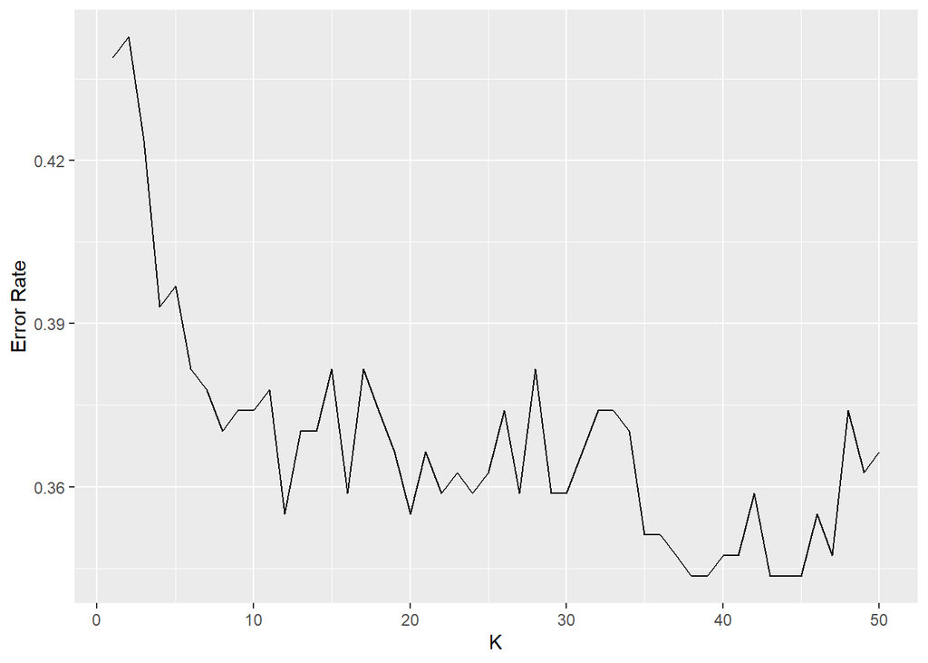

```r
library(ggplot2)
qplot(1:50, error_rate,
      xlab = "K",
      ylab = "Error Rate",
      geom=c("line"))
```

```r
knn_pred_y = knn(train.x, test.x, train.y, k = K[1])
table(knn_pred_y, test.y)
```

```
##           test.y
## knn_pred_y  0  1
##          0 88 38
##          1 54 82
```

```r
prob_knn <-function(Xtrain, Xtest, Ytrain, k){
  #proba à posteriori d'être dans la classe 1 : P(Y=1/X=x)
  prob <-rep(NA,nrow(Xtest))
  res <-knn(Xtrain, Xtest, Ytrain, k=k, prob=TRUE)
  prob[res==1] <-attr(res,"prob")[res==1]
  prob[res==0] <- 1-attr(res,"prob")[res==0]
  return(prob)}


score<-prob_knn(train.x, test.x, train.y, k = K[1])
```

## Arbre de decision (Rpart)

Nous essayons en créant un arbre de classification Rpart. Nous reprennons les deux dataset de notre modèle logistique.

```r
tree.train<-glm.train
tree.test<-glm.test[-c(8:9)]
```

Nous developpons un premier arbre de decision complet.

[figure not shown]

```r
Default.Tree <- rpart(participation~.,data=tree.train,method="class", control=rpart.control(minsplit=5,cp=0))


#Affichage du résultat
plot(Default.Tree, uniform=TRUE, branch=0.5, margin=0.1)
text(Default.Tree, all=FALSE, use.n=TRUE)
```

Nous cherchons à trouver le nombre de profondeur optimal pour notre arbre, pour cela nous cherchon le niveau de cp qui minimise l’erreur relative de notre arbre.

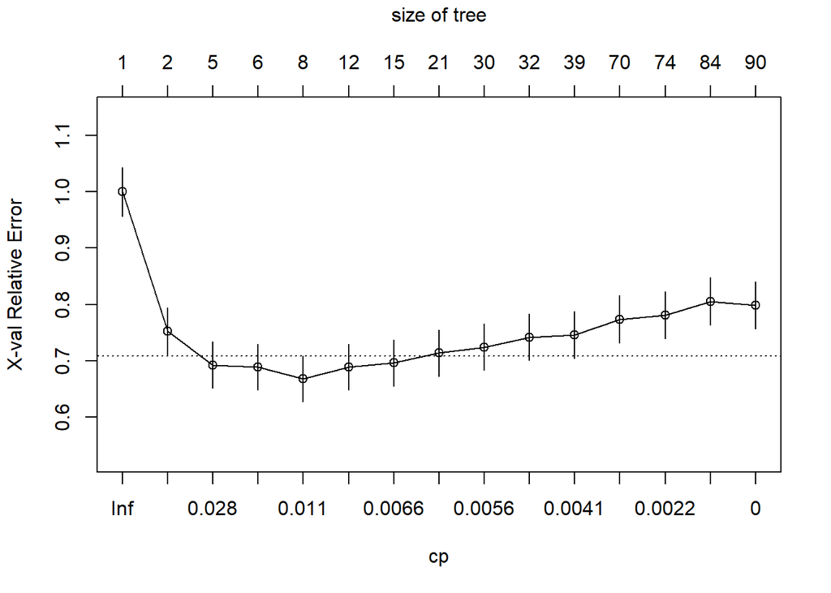

```r
plotcp(Default.Tree)
```

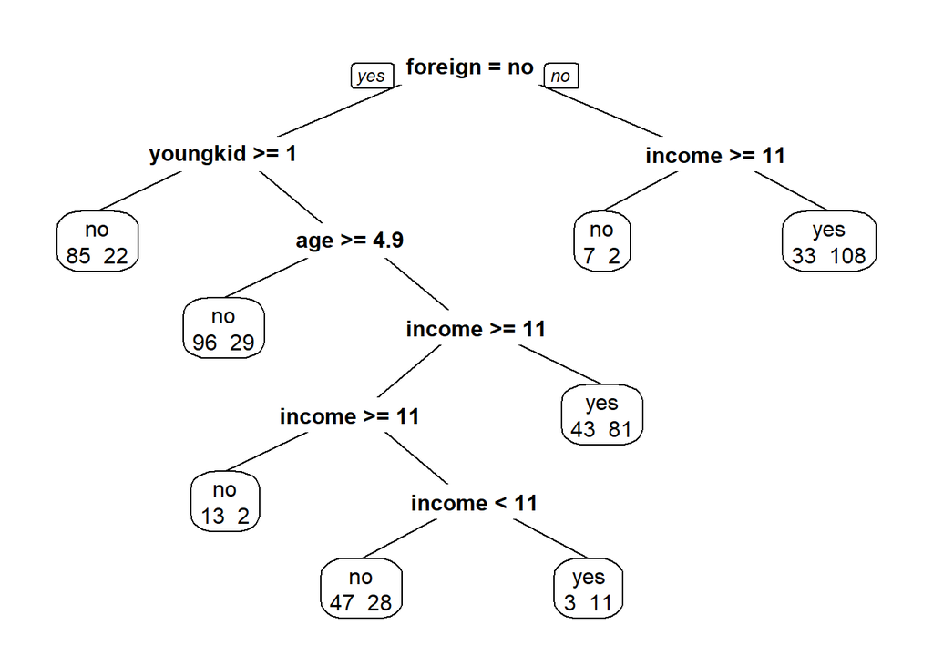

```r
Default.Tree_Opt<-prune(Default.Tree,cp=Default.Tree$cptable[which.min(Default.Tree$cptable[,4]),1])

#Représentation graphique de l’arbre optimal
prp(Default.Tree_Opt,extra=1)
```

Nous remarquons qu’avec notre arbre, ce sont les variables foreign, income, age et youngkid qui permettent de classer nos individus dans dans les catégories de participation.

Nous verifions maintenant la performance de notre modèle à l’aide d’une matrice de confusion.

```r
#Prédiction du modèle sur les données de test
tree.test$tree_predict<-predict(Default.Tree_Opt,newdata=tree.test, type="class")
tree_prob<-as.data.frame(predict(Default.Tree_Opt,newdata=tree.test, type="prob"))

#Matrice de confusion
mc<-table(tree.test$participation,tree.test$tree_predict)
print(mc)
```

```
##
##       no yes
##   no  95  49
##   yes 42  76
```

```r
#Erreur de classement
erreur.classement<-1.0-(mc[1,1]+mc[2,2])/sum(mc)
print("Erreur de classement")
```

```
## [1] "Erreur de classement"
```

```r
print(erreur.classement*100)
```

```
## [1] 34.73282
```

```r
#Taux de prédiction
print("Taux de prediction")
```

```
## [1] "Taux de prediction"
```

```r
prediction=mc[2,2]/sum(mc[2,])
print(prediction*100)
```

```
## [1] 64.40678
```

Notre arbre de classification est donc capable de prédire la variable participation avec un taux de reussite proche de 65%.

# Evaluation du meilleure modèle

Afin de choisir le meilleur modèle entre notre regression logistique et notre arbre de classification, nous realiserons des courbes ROC afin de mesurer l’AUC de nos modèle et determiner qui est le meilleur.

## Courbe ROC

```r
par(mfrow = c(2, 2))
pred=prediction(glm.test$glm_predict,glm.test$participation)
perf<-performance(pred,"auc")
#Resultat de l'AUC
perf@y.values-> LOGIT_AUC
LOGIT_AUC<-round(as.numeric(LOGIT_AUC),2)
perf=performance(pred,"tpr","fpr")
ROC_logit<-plot(perf,main="Courbe ROC LOGIT",sub=LOGIT_AUC)
ROC_logit
```

```r
colnames(tree_prob)[2]<-"Yes"
pred=prediction(tree_prob$Yes,tree.test$participation)

perf<-performance(pred,"auc")
#Resultat de l'AUC
perf@y.values-> TREE_AUC
TREE_AUC<-round(as.numeric(TREE_AUC),2)
perf=performance(pred,"tpr","fpr")
ROC_Tree<-plot(perf,main="Courbe ROC TREE",sub=TREE_AUC)
ROC_Tree
```

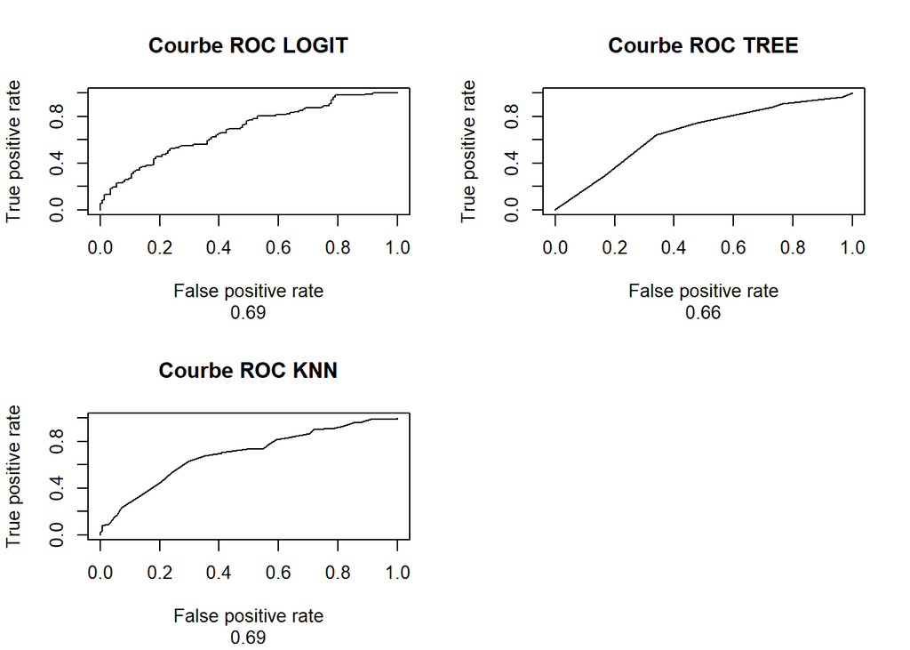

```r
pred=prediction(score,test.y)

perf<-performance(pred,"auc")
#Resultat de l'AUC
perf@y.values-> KNN_AUC
KNN_AUC<-round(as.numeric(KNN_AUC),2)
perf=performance(pred,"tpr","fpr")
ROC_KNN<-plot(perf,main="Courbe ROC KNN",sub=KNN_AUC)
ROC_KNN
```